# Лабораторная работа № 13

Программирование в командном процессоре ОС UNIX. Ветвления и циклы

Чжан Вэньцзюнь

Российский университет дружбы народов

РУДН

2026-10-20

# Информация

## Докладчик

- Чжан Вэньцзюнь
- зачётная книжка № 1132259051
- Российский университет дружбы народов им. П. Лумумбы

## Цель работы

- Изучить основы программирования в оболочке ОС UNIX
- Научиться писать более сложные командные файлы
- Освоить логические управляющие конструкции и циклы

## Задание

1. Скрипт с `getopts` и `grep`: ключи `-i`, `-o`, `-p`, `-C`, `-n`
2. Программа на C с `exit(n)` и анализ `$?` в командном файле
3. Скрипт создания и удаления N файлов `1.tmp`…`N.tmp`
4. Скрипт упаковки в `tar` файлов каталога (изменённых менее недели назад)

# Выполнение работы

## 1. getopts и grep

```bash
while getopts "i:o:p:Cnh" opt; do
  case $opt in
    i) IN="$OPTARG" ;;
    o) OUT="$OPTARG" ;;
    p) PAT="$OPTARG" ;;
    C) SENS=1 ;;
    n) NUMS=1 ;;
  esac
done
grep $OPTS -- "$PAT" "$IN"
```

- `-C` — учитывать регистр (без ключа — `grep -i`)
- `-n` — номера строк, `-o` — вывод в файл
- `-i`, `-p` — обязательные ключи

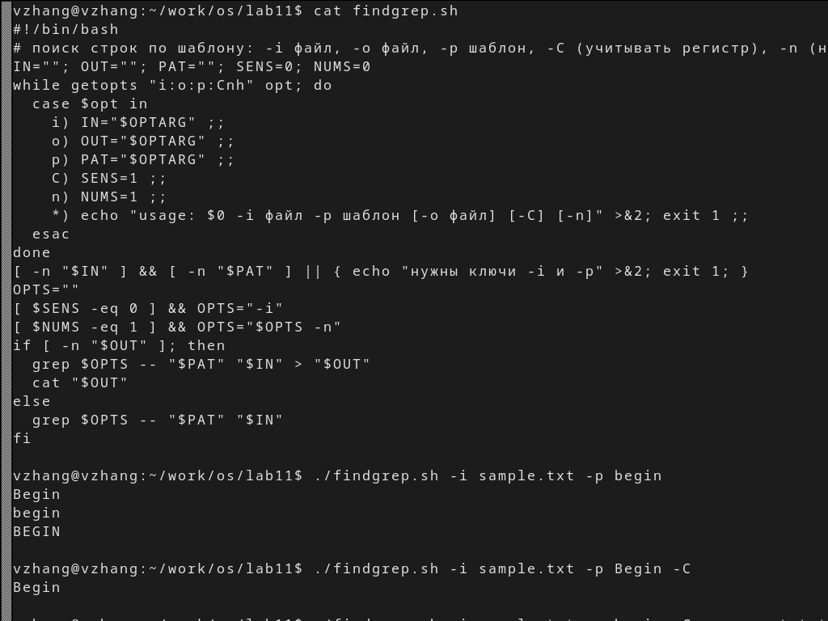

Работа findgrep.sh

## 2. Программа на C и код возврата

```c
if (n > 0) return 0;   /* больше нуля */
if (n < 0) return 1;   /* меньше нуля */
return 3;              /* равно нулю  */
```

```bash
echo "$x" | ./sign
case $? in
  0) echo "больше нуля" ;;
  1) echo "меньше нуля" ;;
  3) echo "равно нулю" ;;
esac
```

- коды возврата: 0 / 1 / 3
- командный файл анализирует `$?`

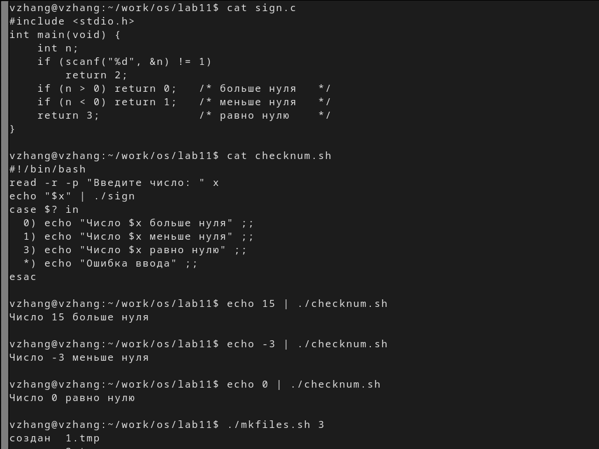

sign.c, checknum.sh и анализ $?

## 3. Создание N файлов

```bash
MODE=create
[ "$1" = "-d" ] && { MODE=delete; shift; }
n=1
while [ "$n" -le "$N" ]; do
  if [ "$MODE" = create ]; then touch "$n.tmp"
  else rm -f "$n.tmp"; fi
  n=$((n+1))
done
```

- `./mkfiles.sh 5` — создать `1.tmp`…`5.tmp`
- `./mkfiles.sh -d 5` — удалить их
- цикл `while` с инкрементом

## 4. Упаковка в tar

```bash
find "$DIR" -maxdepth 1 -type f -mtime -7 -print0 \
  | tar -czf "$ARCH" --null -T -
```

- `-mtime -7` — изменённые менее недели назад
- `-print0` + `tar --null -T -` — безопасно для имён с пробелами
- `tar -tzf` — проверка содержимого архива

# Заключение

## Выводы

- Изучены управляющие конструкции `if`, `case`, `while`, `until`, `for`
- Освоена команда `getopts` для разбора ключей
- Написан скрипт поиска с `grep` и анализом регистра
- Программа на C передаёт результат через `exit(n)`, скрипт анализирует `$?`
- Освоены `find -mtime` и `tar` для архивации

## Спасибо за внимание!

Вопросы?